# Applied Computational Methods for Social Sciences

Lecture 20: Geometric Operations with Rasters 2 — Mosaicing, Resampling, Reprojecting

Bogdan G. Popescu

bogdan.popescu@johncabot.edu

John Cabot University

## What You’ll Learn Today

1. Loading **elevation DEM tiles** for whole continents
2. **Mosaicing** rasters into one seamless layer
3. **Resampling** to different resolutions
4. **Reprojecting** rasters between coordinate systems
5. A look at **3D terrain rendering**

By the end, you’ll be able to stitch, rescale, and reproject gridded elevation data.

## Mosaicing Rasters

In this lecture, we will look at other types of operations that we can perform on rasters:

- Mosaicing
- resampling
- reprojecting

We will continue to use packages like `stars` and `units`

## Mosaicing: Elevation

We will demonstrate the use the three tools, by applying them to a Digital Elevation Model (DEM).

This is what we try to achieve:

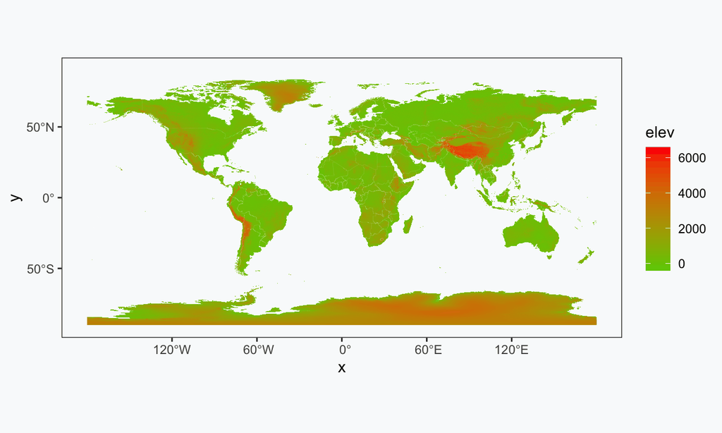

## Downloading DEM data

DEM stands for a digital elevation model

There are many data sources

The most helpful website for downloading DEM is: http://www.webgis.com/terr_world.html

## Working with Elevation

[figure not shown]

## Working with Elevation

[figure not shown]

## Working with Elevation

[figure not shown]

## Working with Elevation

To save time, you can [download the DEM](https://www.dropbox.com/scl/fi/rc5esu746lxkpxvn2h47p/elevation.zip?rlkey=vxc8eb4mv18x0ie53qwa2m1lb&dl=0).

You can also [download the world borders](https://www.dropbox.com/scl/fi/sqjjzeuzs63dxmraluwfr/boundaries.zip?rlkey=jlwgmqf4zmkjbqhohv4r7nogn&dl=0).

## Working with Elevation

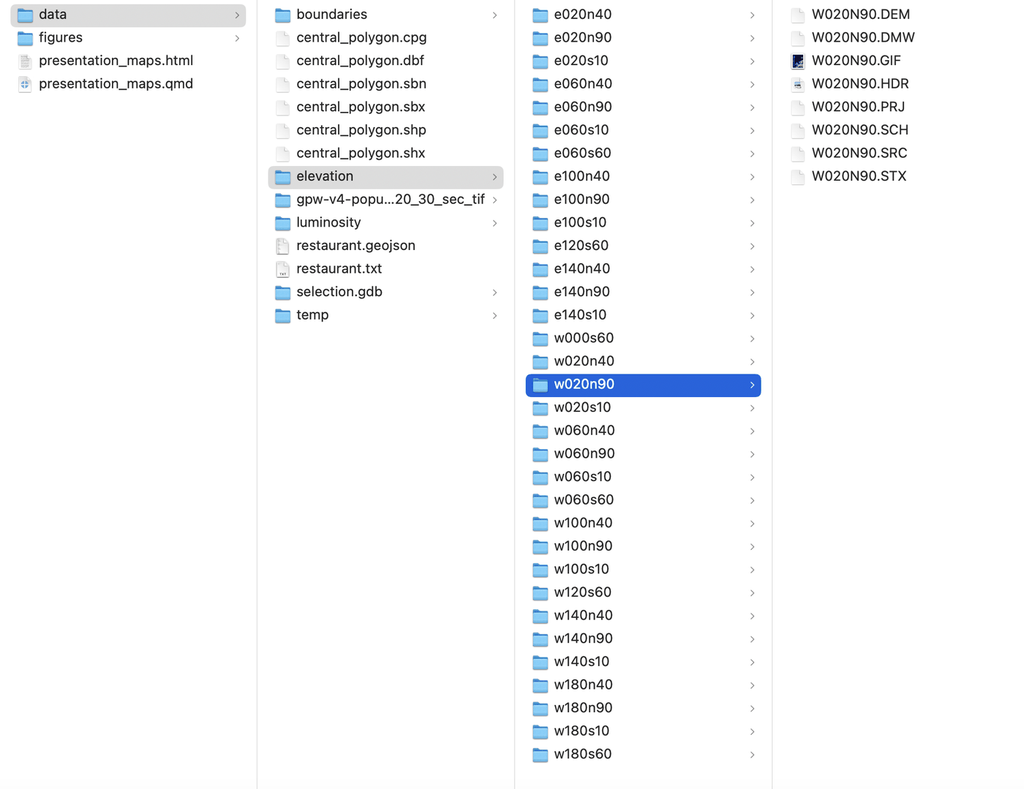

## Elevation

This is what the these individual files look like:

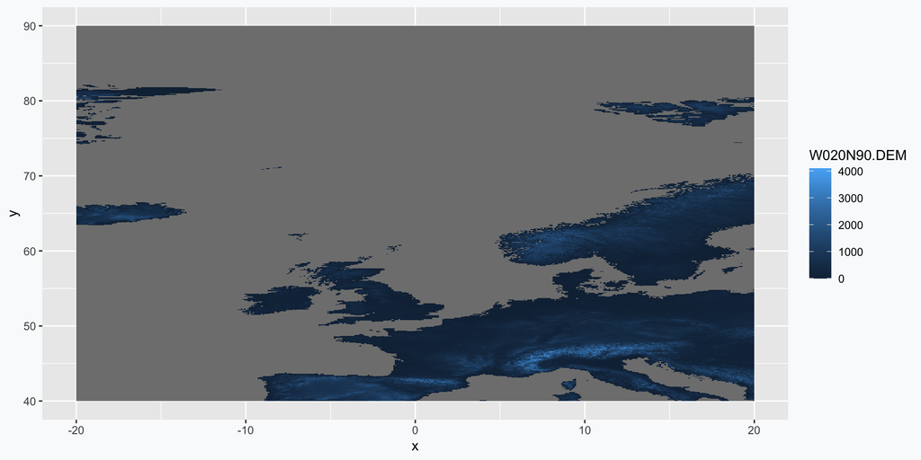

```r
#Step1: Load the DEM files for every continent
#EUROPE
filepath<-"./data/elevation/w020n90/W020N90.DEM"
x1<-read_stars(filepath)
#Reducing the resolution
x1_simple<-st_warp(x1, st_as_stars(st_bbox(x1), dx = 0.1, dy = 0.1))
#Mapping
ggplot()+
  geom_stars(data=x1_simple)
```

## Elevation

We will now try to stitch all these files together

```r
#Step1: Load the DEM files for every continent
#EUROPE
filepath<-"./data/elevation/w020n90/W020N90.DEM"
x1<-read_stars(filepath)
filepath<-"./data/elevation/w020n40/w020n40.DEM"
x2<-read_stars(filepath)
filepath<-"./data/elevation/e020n40/e020n40.DEM"
x3<-read_stars(filepath)
filepath<-"./data/elevation/e020n90/e020n90.DEM"
x4<-read_stars(filepath)
filepath<-"./data/elevation/w060n40/w060n40.DEM"
x5<-read_stars(filepath)
filepath<-"./data/elevation/w060n90/w060n90.DEM"
x6<-read_stars(filepath)
```

## Elevation

```r
#ASIA
filepath<-"./data/elevation/e140n40/e140n40.DEM"
x7<-read_stars(filepath)
filepath<-"./data/elevation/e140n90/e140n90.DEM"
x8<-read_stars(filepath)
filepath<-"./data/elevation/e060n40/e060n40.DEM"
x9<-read_stars(filepath)
filepath<-"./data/elevation/e060n90/e060n90.DEM"
x10<-read_stars(filepath)
filepath<-"./data/elevation/e100n40/e100n40.DEM"
x11<-read_stars(filepath)
filepath<-"./data/elevation/e100n90/e100n90.DEM"
x12<-read_stars(filepath)

#AUSTRALIA
filepath<-"./data/elevation/e060s10/e060s10.DEM"
x13<-read_stars(filepath)
filepath<-"./data/elevation/e100s10/e100s10.DEM"
x14<-read_stars(filepath)
filepath<-"./data/elevation/e140s10/e140s10.DEM"
x15<-read_stars(filepath)
filepath<-"./data/elevation/e060s60/e060s60.DEM"
x16<-read_stars(filepath)
filepath<-"./data/elevation/e120s60/e120s60.DEM"
x17<-read_stars(filepath)
```

## Elevation

```r
#NORTH AMERICA
filepath<-"./data/elevation/w180n90/w180n90.DEM"
x18<-read_stars(filepath)
filepath<-"./data/elevation/w140n90/w140n90.DEM"
x19<-read_stars(filepath)
filepath<-"./data/elevation/w100n90/w100n90.DEM"
x20<-read_stars(filepath)
filepath<-"./data/elevation/w180n40/w180n40.DEM"
x21<-read_stars(filepath)
filepath<-"./data/elevation/w140n40/w140n40.DEM"
x22<-read_stars(filepath)
filepath<-"./data/elevation/w100n40/w100n40.DEM"
x23<-read_stars(filepath)

#SOUTH AMERICA
filepath<-"./data/elevation/w180s10/w180s10.DEM"
x24<-read_stars(filepath)
filepath<-"./data/elevation/w140s10/w140s10.DEM"
x25<-read_stars(filepath)
filepath<-"./data/elevation/w100s10/w100s10.DEM"
x26<-read_stars(filepath)
filepath<-"./data/elevation/w180s60/w180s60.DEM"
x27<-read_stars(filepath)
filepath<-"./data/elevation/w120s60/w120s60.DEM"
x28<-read_stars(filepath)

#SOUTH AFRICA
filepath<-"./data/elevation/w060s10/w060s10.DEM"
x29<-read_stars(filepath)
filepath<-"./data/elevation/w020s10/w020s10.DEM"
x30<-read_stars(filepath)
filepath<-"./data/elevation/e020s10/e020s10.DEM"
x31<-read_stars(filepath)
filepath<-"./data/elevation/w060s60/w060s60.DEM"
x32<-read_stars(filepath)
filepath<-"./data/elevation/w000s60/w000s60.DEM"
x33<-read_stars(filepath)
```

## Elevation

```r
#Step2: Creating a mosaic
library(ggplot2)
star_mosaic_eu <- st_mosaic(x1, x2, x3, x4, x5, x6)
#Reducing the resolution
star_mosaic_eu<-st_warp(star_mosaic_eu, st_as_stars(st_bbox(star_mosaic_eu), dx = 0.4, dy = 0.4))
#Removing from memory irrelevant files
rm(x1, x2, x3, x4, x5, x6)

star_mosaic_rus <- st_mosaic(x7, x8, x9, x10, x11, x12)
#Reducing the resolution
star_mosaic_rus<-st_warp(star_mosaic_rus, st_as_stars(st_bbox(star_mosaic_rus), dx = 0.4, dy = 0.4))
#Removing from memory irrelevant files
rm(x7, x8, x9, x10, x11, x12)

star_mosaic_aus <- st_mosaic(x13, x14, x15, x16, x17)
#Reducing the resolution
star_mosaic_aus<-st_warp(star_mosaic_aus, st_as_stars(st_bbox(star_mosaic_aus), dx = 0.4, dy = 0.4))
#Removing from memory irrelevant files
rm(x13, x14, x15, x16, x17)

star_mosaic_namer <- st_mosaic(x18, x19, x20, x21, x22, x23)
#Reducing the resolution
star_mosaic_namer<-st_warp(star_mosaic_namer, st_as_stars(st_bbox(star_mosaic_namer), dx = 0.4, dy = 0.4))
#Removing from memory irrelevant files
rm(x18, x19, x20, x21, x22, x23)

star_mosaic_samer <- st_mosaic(x24, x25, x26, x27, x28)
#Reducing the resolution
star_mosaic_samer<-st_warp(star_mosaic_samer, st_as_stars(st_bbox(star_mosaic_samer), dx = 0.4, dy = 0.4))
#Removing from memory irrelevant files
rm(x24, x25, x26, x27, x28)

star_mosaic_safr <- st_mosaic(x29, x30, x31, x32, x33)
#Reducing the resolution
star_mosaic_safr<-st_warp(star_mosaic_safr, st_as_stars(st_bbox(star_mosaic_safr), dx = 0.4, dy = 0.4))
#Removing from memory irrelevant files
rm(x29, x30, x31, x32, x33)
```

## Elevation

```r
#Step3: Creating a second mosaic
all<-st_mosaic(star_mosaic_eu, star_mosaic_rus, star_mosaic_aus, star_mosaic_namer, star_mosaic_samer, star_mosaic_safr)

#Step4: Higher dx/day values means lower resolution
elev<-st_warp(all, st_as_stars(st_bbox(all), dx = 0.4, dy = 0.4))

#Step5: Renaming the raster file
names(elev)<-"elev"

#Step6: Ensuring the the raster has the same crs
borders <- st_read(dsn="./data/boundaries/all-country-boundaries.shp", quiet = TRUE)
borders <- st_simplify(borders, dTolerance = 0.05)
#Turning off spherical geometries
sf_use_s2(FALSE)
st_crs(elev)<-st_crs(borders)

#Step7: Mapping
fig<-ggplot()+
  geom_stars(data=elev)+
  scale_fill_gradientn(colours=c("chartreuse3","red"),   na.value = NA)+
  geom_sf(data=borders, linewidth = 0.01, fill = NA, color = "white", alpha=0.5)+
  theme_bw()+
  theme(panel.grid.major = element_blank(), panel.grid.minor = element_blank())
```

## Digital Elevation Model (DEM)

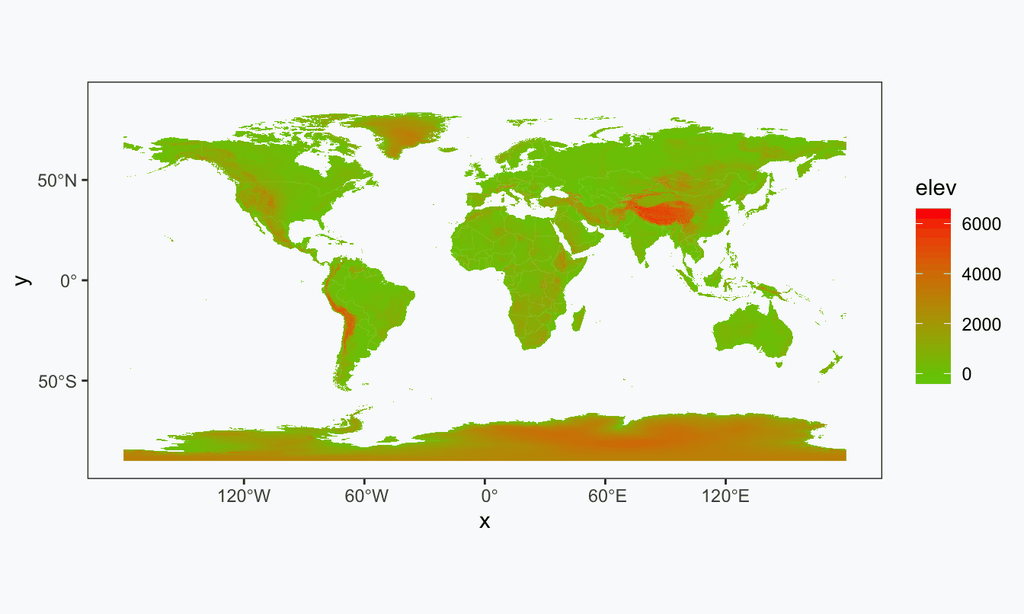

## Digital Elevation Model (DEM)

If we don’t mosaic the different tiles, we only have one.

This is what the tile for Europe looks like.

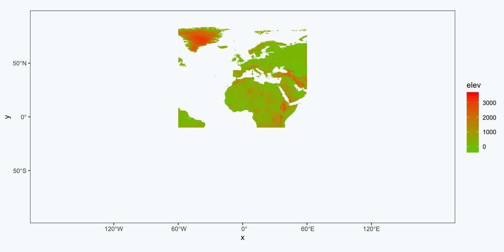

## Digital Elevation Model (DEM) in Europe

This is how we identify the coordinates of our frame.

```r
#Identifying coordinates of Northern points
#Step1: Selecting the country
norway<-subset(borders, SOVEREIGNT == "Norway")
#Step2: Extracting its coordinates
max_lat_y_eu<-st_bbox(norway)["ymax"]

#Identifying coordinates of Southern points
#Step1: Selecting the country
greece<-subset(borders, SOVEREIGNT == "Greece")
#Step2: Extracting its coordinates
min_lat_y_eu<-st_bbox(greece)["ymin"]

#Identifying coordinates of Eastern points
ukraine<-subset(borders, SOVEREIGNT == "Ukraine")
#Step2: Extracting its coordinates
max_lon_x_eu<-st_bbox(ukraine)["xmax"]

#Identifying coordinates of Western points
#Step1: Selecting the country
portugal<-subset(borders, SOVEREIGNT == "Portugal")
#Step2: Extracting its coordinates
min_lon_x_eu<-st_bbox(portugal)["xmin"]
```

## Digital Elevation Model (DEM) in Europe

```r
#Step1: Higher dx/day values mean lower resolution
all2<-st_warp(all, st_as_stars(st_bbox(all), dx = 0.1, dy = 0.1))
#Step2: Renaming raster values
names(all2)<-"elev"
#Step3: Mapping
fig<-ggplot()+
  geom_stars(data=all2)+
  scale_fill_gradientn(colours=c("chartreuse3","red"),   na.value = NA)+
  geom_sf(data=borders, linewidth = 0.05, fill = NA, color = "white", alpha=0.5)+
  coord_sf(xlim = c(min_lon_x_eu-3, max_lon_x_eu+3), ylim = c(min_lat_y_eu-1, max_lat_y_eu-6), expand = FALSE)+
  theme_bw()+
  theme(panel.grid.major = element_blank(), panel.grid.minor = element_blank())
```

## Digital Elevation Model (DEM) in Europe

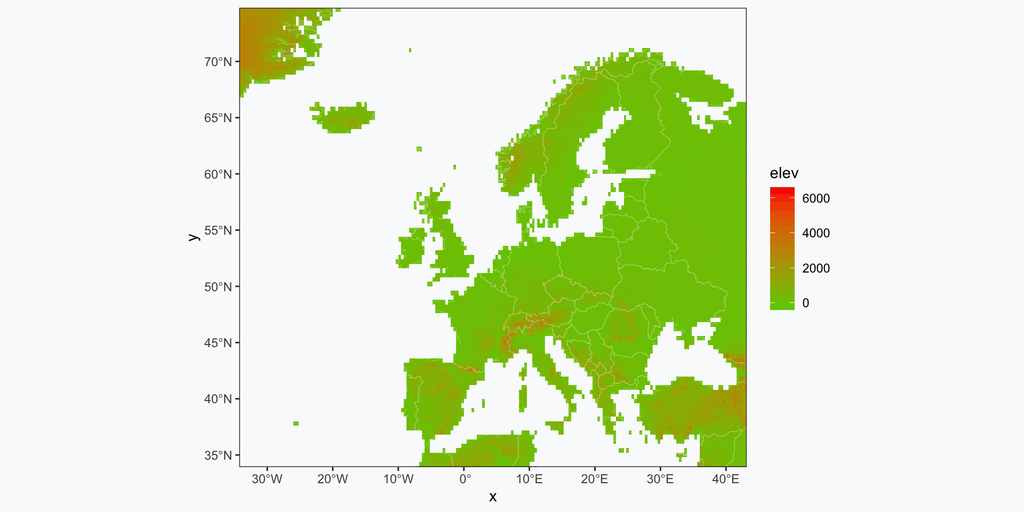

## Digital Elevation Model (DEM) in the US

We can do the same thing for the US

```r
#Step1: Higher dx/day values mean lower resolution
all2<-st_warp(all, st_as_stars(st_bbox(all), dx = 0.1, dy = 0.1))
#Step2: Renaming raster values
names(all2)<-"elev"
#Step3: Identifying the coordinates for the map
min_lon_x_us<-(-130)
max_lon_x_us<-(-57)
min_lat_y_us<-(26)
max_lat_y_us<-(53)
#Step4: Mapping
fig<-ggplot()+
  geom_stars(data=all2)+
  scale_fill_gradientn(colours=c("chartreuse3","red"),   na.value = NA)+
  geom_sf(data=borders, linewidth = 0.05, fill = NA, color = "white", alpha=0.5)+
  coord_sf(xlim = c(min_lon_x_us-3, max_lon_x_us+3), ylim = c(min_lat_y_us-3, max_lat_y_us+3), expand = FALSE)+
  theme_bw()+
  theme(panel.grid.major = element_blank(), panel.grid.minor = element_blank())
```

## Digital Elevation Model (DEM) in the US

We can do the same thing for the US:

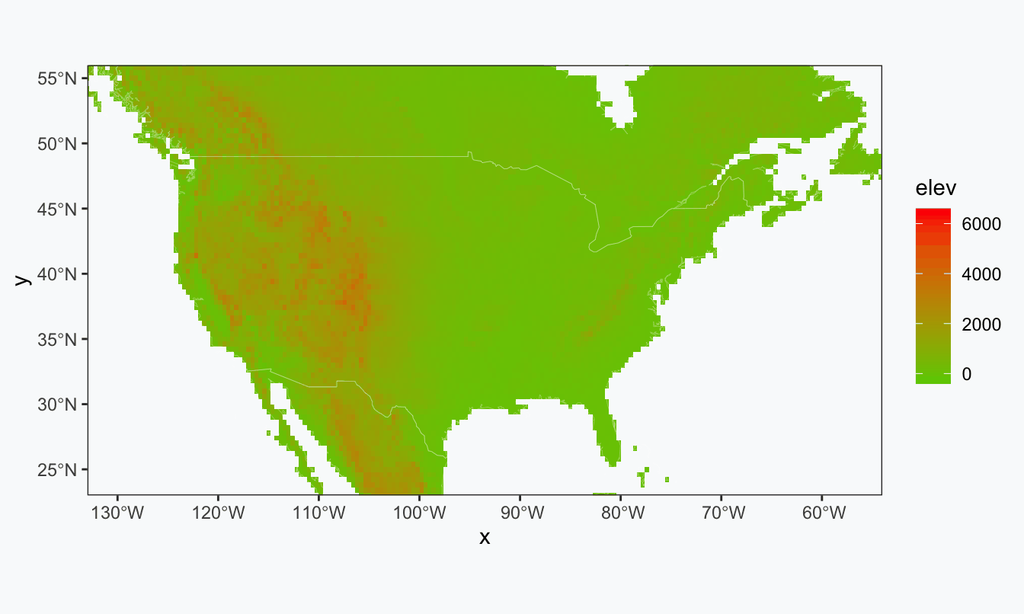

## Elevation 3D

```r
#Step1: Turning the raster into points
elev2<-st_as_sf(elev, as_points = FALSE, merge = FALSE)
#Step2: Mapping
fig1<-ggplot() +
  geom_sf(data = elev2, aes(fill = elev), color=NA) +
  scale_fill_gradient(low = "chartreuse3", high = "red")+
  geom_sf(data=borders, linewidth = 0.01, fill = NA, color = "white", alpha=0.5)+
  theme_bw()
#Note: May not always work
#Step3: Creating the movie
#Manually install https://www.xquartz.org
#library("av")
#install.packages("devtools")
#devtools::install_github("tylermorganwall/rayshader")
#library("rayshader")
#plot_gg(fig1,multicore=TRUE,width=7,height=3,scale=350)    # Plot_gg de rayshader
#render_snapshot(filename = "Elevation")
#render_movie("./figures/movie_elev.mp4",frames = 720, fps=30,zoom=0.8,fov = 30)
```

## Elevation 3D

[video not shown]

## Raster Resampling

Raster resampling is the process of transferring raster values from the original grid to a different grid.

Resampling may be necessary for:

- aligning several input rasters that come from different sources to the same grid
- reducing the resolution of very detailed rasters, so that they are more convenient to work with

## Raster Resampling

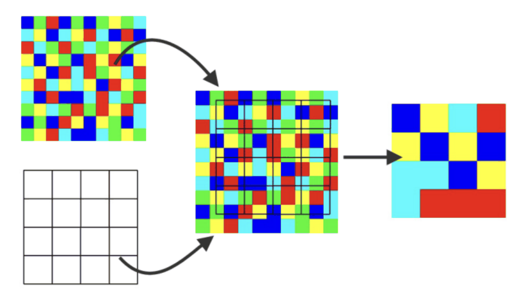

## Raster Resampling

In case you have not noticed, we have already resampled the DEM raster.

```r
#Step4: Higher dx/day values means lower resolution
elev<-st_warp(all, st_as_stars(st_bbox(all), dx = 0.4, dy = 0.4))

#Step5: Renaming the raster file
names(elev)<-"elev"

#Step6: Ensuring the the raster has the same crs
st_crs(elev)<-st_crs(borders)

fig<-ggplot()+
  geom_stars(data=elev)+
  scale_fill_gradientn(colours=c("chartreuse3","red"),   na.value = NA)+
  geom_sf(data=borders, linewidth = 0.01, fill = NA, color = "white", alpha=0.5)+
  theme_bw()+
  theme(panel.grid.major = element_blank(), panel.grid.minor = element_blank())
```

## Nearest Neighbor Resampling

There are a variety of other re-sampling methods.

In the nearest neighbor sampling, the new raster pixels get the value from the nearest pixel of the original raster.

Some values may be lost.

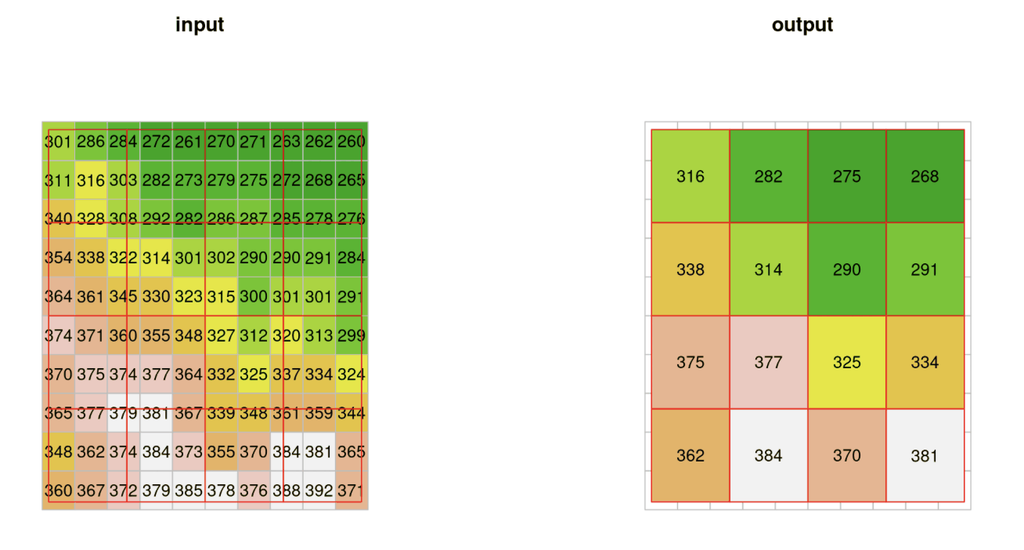

## Nearest Neighbor Resampling

```r
#Step4: Lower dx values. Lower dx values means lower resolution
grid = st_as_stars(st_bbox(all), dx = 0.4, dy = 0.4)
dem1 = st_warp(elev, grid, method = "near")

fig<-ggplot()+
  geom_stars(data=dem1)+
  scale_fill_gradientn(colours=c("chartreuse3","red"),   na.value = NA)+
  geom_sf(data=borders, linewidth = 0.01, fill = NA, color = "white", alpha=0.5)+
  theme_bw()+
  theme(panel.grid.major = element_blank(), panel.grid.minor = element_blank())
fig
```

## Bilinear resampling

In bilinear resampling, each new raster cell gets a *weighted average of four* nearest cells from the input, rather than just one.

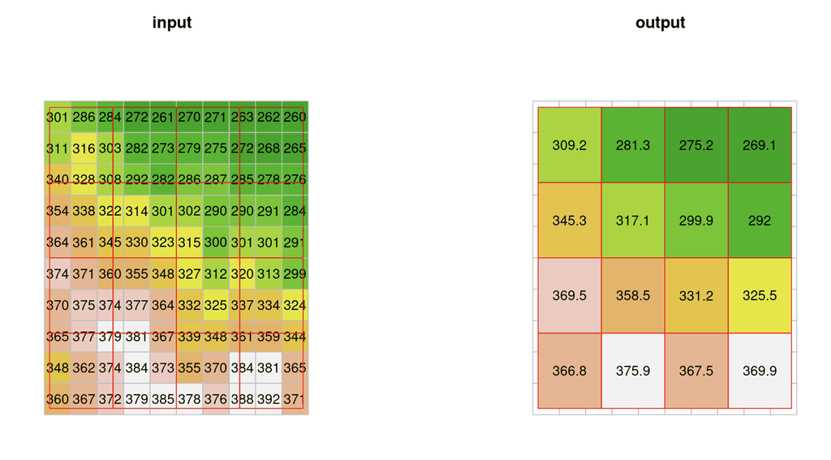

## Bilinear resampling

Two technical things to note about st_warp when using a method other than `method="near"`:

- `use_gdal=TRUE` needs to be specified, otherwise the `method` argument is ignored
- `no_data_value` needs to be set to a value outside of the valid range (such as `no_data_value=-9999` for a DEM raster)

```r
dem2 = st_warp(elev, grid, method = "bilinear", use_gdal = TRUE, no_data_value = -9999)
```

## Average resampling

Another useful method is the average resampling method, where each new cell gets the weighted average of all overlapping input cells:

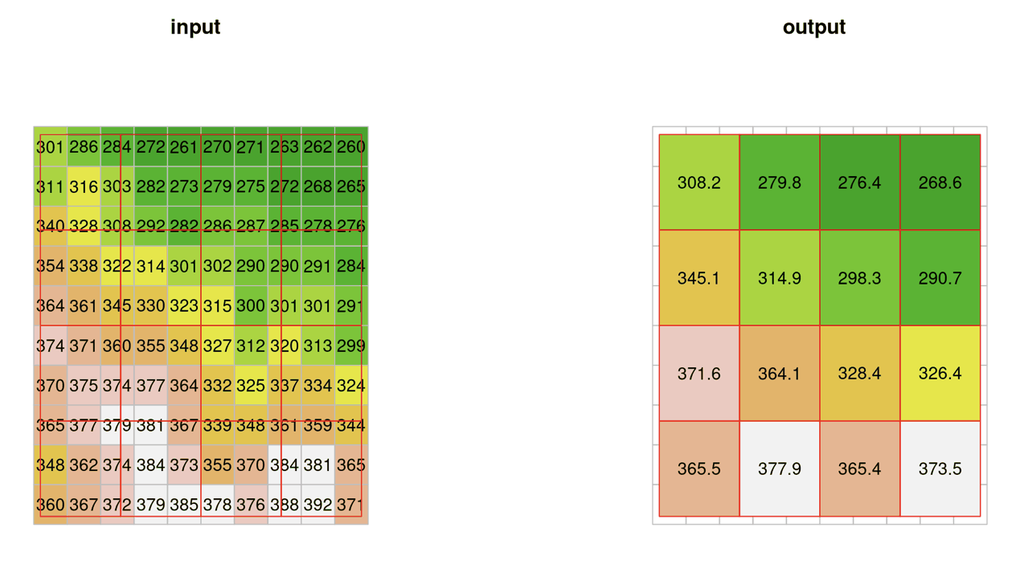

## Average resampling

```r
dem3 = st_warp(elev, grid, method = "average", use_gdal = TRUE, no_data_value = -9999)
```

## Raster Reprojection

Raster reprojection is more complex than vector layer reprojection.

It requires both transforming pixel coordinates and a resampling step in order to “arrange” the transformed values back into a regular grid.

While other sources recommend `st_warp` for reprojection, this puts a lot of pressure on your computer’s memory.

## Raster Reprojection

```r
#Step1: Reprojecting the shapefile to EPSG:32636
borders_rep<-st_transform(borders, crs = 32636)
#Step2: Subsetting countries
italy<-subset(borders_rep, SOVEREIGNT=="Italy")
#Step3: Reducing the original resolution: Higher dx/day values mean lower resolution
elev<-st_warp(all, st_as_stars(st_bbox(all), dx = 0.4, dy=0.4))
#Step4: Turning the raster to a raster object
dem_rep <- terra::rast(elev)
#Step5: Re-projecting the rasters
dem_rep<-terra::project(dem_rep, terra::crs(borders_rep))
#Step6: Turning the raster back to a stars object
dem_rep<-st_as_stars(dem_rep)

#The following section is to indetify the min max of Italy in ordet to map it.
#Step7: Making a box object around the polygon
bbox <- st_bbox(italy)

#Step8: Extracting min and max latitudes and longitudes
min_lat_y <- bbox["ymin"]
max_lat_y <- bbox["ymax"]
min_lon_x <- bbox["xmin"]
max_lon_x <- bbox["xmax"]

#Step9: Adding an error
error<-10000000
#Step10: Mapping
fig<-ggplot()+
  geom_stars(data=dem_rep)+
  scale_fill_gradientn(colours=c("chartreuse3","red"),   na.value = NA)+
  #geom_sf(data=italy, linewidth = 0.01, fill = NA, color = "black", alpha=0.5)
  geom_sf(data=italy, linewidth = 0.1, fill = NA)+
  geom_sf(data=borders_rep, linewidth = 0.1, fill = NA)+
  coord_sf(xlim = c(min_lon_x - error, max_lon_x + error),
           ylim = c(min_lat_y - error, max_lat_y + error))
```

## Raster Reprojection

```r
fig
```

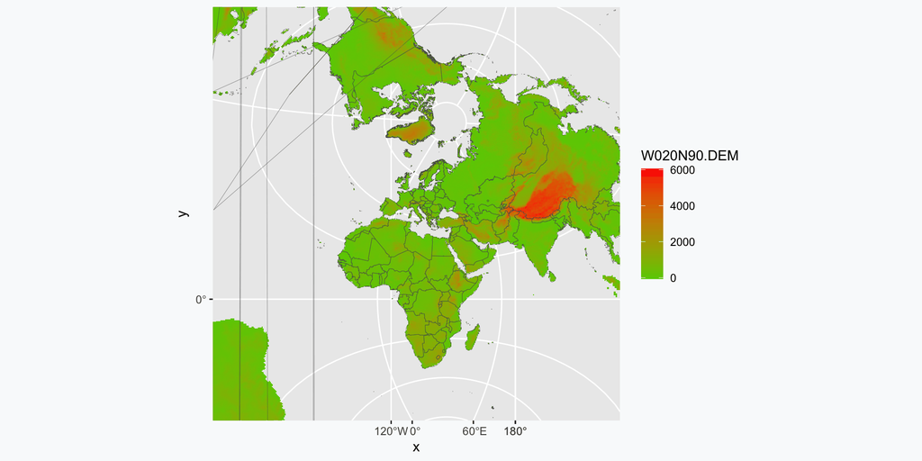

## Raster Reprojection

Note that the coordinate units in the reprojected raster are no longer degrees, but meters.

We can check that by analyzing the output from `st_crs(dem_rep)`

## Raster Reprojection

```r
st_crs(dem_rep)
```

```
Coordinate Reference System:
  User input: WGS 84 / UTM zone 36N
  wkt:
PROJCRS["WGS 84 / UTM zone 36N",
    BASEGEOGCRS["WGS 84",
        ENSEMBLE["World Geodetic System 1984 ensemble",
            MEMBER["World Geodetic System 1984 (Transit)"],
            MEMBER["World Geodetic System 1984 (G730)"],
            MEMBER["World Geodetic System 1984 (G873)"],
            MEMBER["World Geodetic System 1984 (G1150)"],
            MEMBER["World Geodetic System 1984 (G1674)"],
            MEMBER["World Geodetic System 1984 (G1762)"],
            MEMBER["World Geodetic System 1984 (G2139)"],
            MEMBER["World Geodetic System 1984 (G2296)"],
            ELLIPSOID["WGS 84",6378137,298.257223563,
                LENGTHUNIT["metre",1]],
            ENSEMBLEACCURACY[2.0]],
        PRIMEM["Greenwich",0,
            ANGLEUNIT["degree",0.0174532925199433]],
        ID["EPSG",4326]],
    CONVERSION["UTM zone 36N",
        METHOD["Transverse Mercator",
            ID["EPSG",9807]],
        PARAMETER["Latitude of natural origin",0,
            ANGLEUNIT["degree",0.0174532925199433],
            ID["EPSG",8801]],
        PARAMETER["Longitude of natural origin",33,
            ANGLEUNIT["degree",0.0174532925199433],
            ID["EPSG",8802]],
        PARAMETER["Scale factor at natural origin",0.9996,
            SCALEUNIT["unity",1],
            ID["EPSG",8805]],
        PARAMETER["False easting",500000,
            LENGTHUNIT["metre",1],
            ID["EPSG",8806]],
        PARAMETER["False northing",0,
            LENGTHUNIT["metre",1],
            ID["EPSG",8807]]],
    CS[Cartesian,2],
        AXIS["(E)",east,
            ORDER[1],
            LENGTHUNIT["metre",1]],
        AXIS["(N)",north,
            ORDER[2],
            LENGTHUNIT["metre",1]],
    USAGE[
        SCOPE["Navigation and medium accuracy spatial referencing."],
        AREA["Between 30°E and 36°E, northern hemisphere between equator and 84°N, onshore and offshore. Belarus. Cyprus. Egypt. Ethiopia. Finland. Israel. Jordan. Kenya. Lebanon. Moldova. Norway. Russian Federation. Saudi Arabia. Sudan. Syria. Türkiye (Turkey). Uganda. Ukraine."],
        BBOX[0,30,84,36]],
    ID["EPSG",32636]]
```

## Combining Raster and Vector Layers

Now, we will focus on elements related to:

- Cropping and masking a raster according to a vector layer
- Switching from vector to raster representation, and vice versa
- Extracting raster values from locations defined by a vector layer

## Masking and Cropping Rasters

Masking a raster means turning pixels values outside of an area of interest — defined using a polygonal layer — into `NA`.

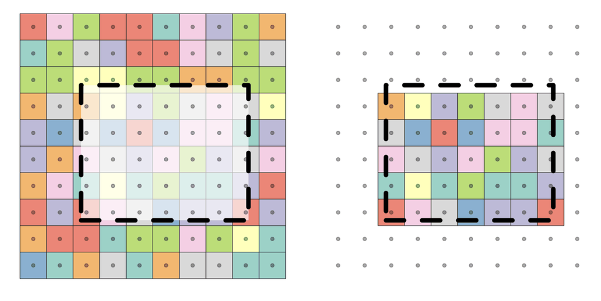

## Masking and Cropping Rasters

```r
#Step1: Only choosing Italy
italy<-subset(borders, SOVEREIGNT=="Italy")
#Step2: Reducing the resolution: Higher dx/day values mean lower resolution
#Loading original files
filepath<-"./data/elevation/w020n90/W020N90.DEM"
x1<-read_stars(filepath)
filepath<-"./data/elevation/w020n40/w020n40.DEM"
x2<-read_stars(filepath)
filepath<-"./data/elevation/e020n40/e020n40.DEM"
#Mosaicing original files
eur<-st_mosaic(x1, x2)
#Reducing resolution
elev<-st_warp(eur, st_as_stars(st_bbox(eur), dx = 0.05, dy = 0.05))
#Step3: Cropping
dem_italy<-st_crop(elev, italy)
#Step4: Renaming the raster file
names(dem_italy)<-"elev"

fig<-ggplot()+
  geom_stars(data=dem_italy)+
  scale_fill_gradientn(colours=c("chartreuse3","red"), na.value = NA)+
  geom_sf(data=italy, linewidth = 0.1, fill = NA)+
  theme_bw()
```

## Masking and Cropping Rasters

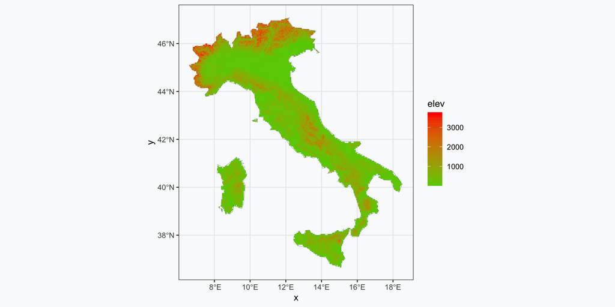

## Turning a Raster into a Vector

It is possible to turn rasters into vectors

We have already seen this in fact.

```r
library(sf)
#Step0: Switched off spherical geometry (s2)
sf::sf_use_s2(FALSE)
#Step1: Only choosing Italy
italy<-subset(borders, SOVEREIGNT=="Italy")
#Step2: Ensuring the same CRS for vector and raster
st_crs(italy)<-st_crs(borders)
st_crs(elev)<-st_crs(borders)
#Step3: Cropping raster
dem_italy<-st_crop(elev, italy)
#Step4: Changing the name
names(dem_italy)<-"elev"
#Step5: Creating a grid from the raster
dem_italy2<-st_as_sf(dem_italy, as_points = FALSE)
#Step6: Changing the name of the vector
names(dem_italy2)[1]<-"elev"
```

## Turning a Raster into a Vector

This fundamentally creates a grid

```r
#Step7: Making a box object around the polygon
bbox <- st_bbox(italy)

#Step8: Extracting min and max latitudes and longitudes
min_lat_y <- bbox["ymin"]
max_lat_y <- bbox["ymax"]
min_lon_x <- bbox["xmin"]
max_lon_x <- bbox["xmax"]

error<-1
fig1<-ggplot()+
  geom_sf(data=dem_italy2, aes(fill=elev), linewidth=0)+
  geom_sf(data=italy, fill=NA)+
  ggtitle("Shapefile")+
  coord_sf(xlim = c(min_lon_x - error, max_lon_x + error),
           ylim = c(min_lat_y - error, max_lat_y + error))

fig2<-ggplot()+
  geom_stars(data=dem_italy)+
  geom_sf(data=italy, fill=NA)+
  scale_fill_continuous(na.value=NA)+
  ggtitle("Raster")+
    coord_sf(xlim = c(min_lon_x - error, max_lon_x + error),
           ylim = c(min_lat_y - error, max_lat_y + error))
```

## Turning a Raster into a Vector

This fundamentally creates a grid

```r
library(ggpubr)
ggarrange(fig1, fig2)
```

## Turning a Raster into a Vector

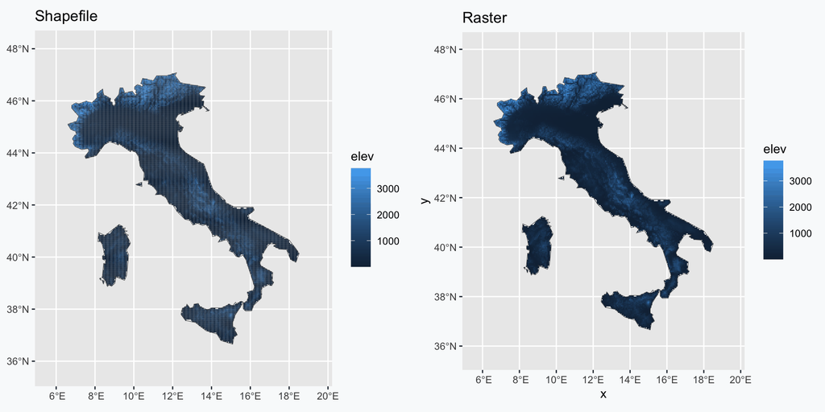

## Extracting Raster Values

It may be necessary to “extract” raster values according to:

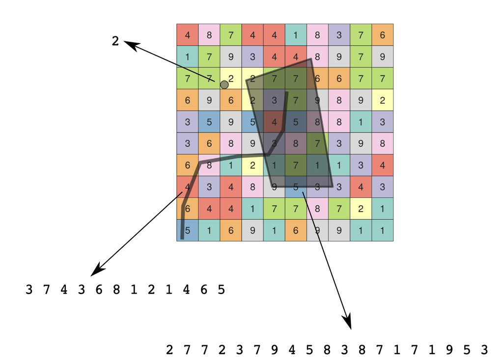

## Extracting Raster Values

It may be necessary to “extract” raster values according to:

- overlapping points

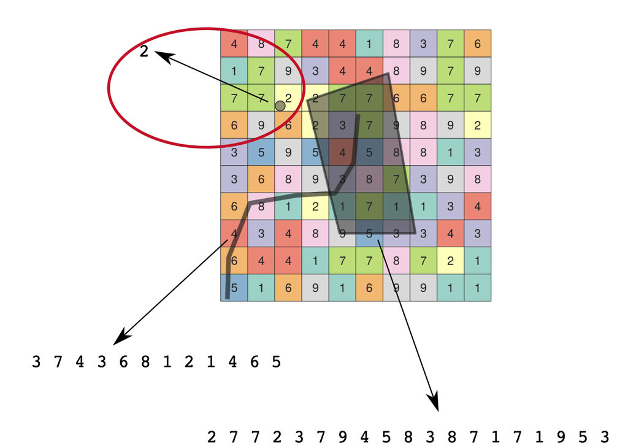

## Extracting Raster Values

It may be necessary to “extract” raster values according to:

- overlapping line

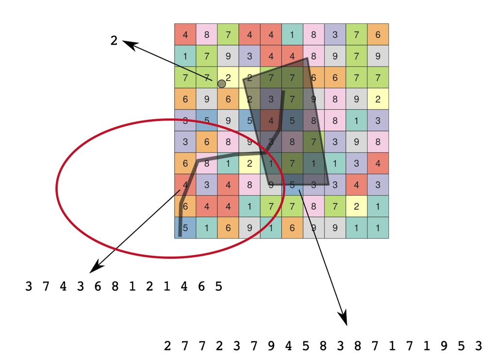

## Extracting Raster Values

It may be necessary to “extract” raster values according to:

- overlapping polygon

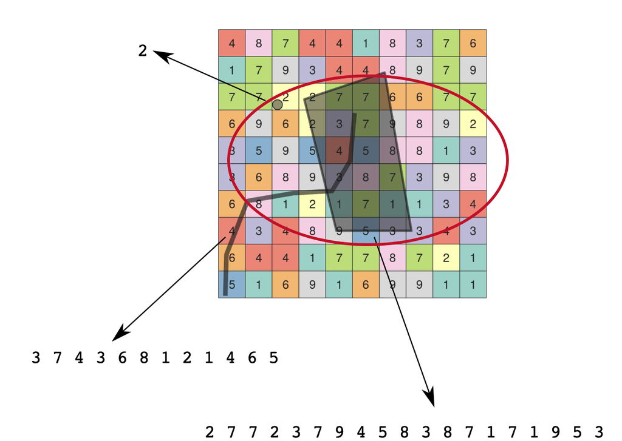

## Extracting Raster Values

We can aggregate and take the average of the raster pixels at the polygon level

You can download the [shapefiles for Italy](https://www.dropbox.com/s/lcp8vngmdswr9nv/gadm41_ITA_shp.zip?dl=0).

```r
library(sf)
library(dplyr)
#Step1: Renaming the raster
names(elev)<-"elev"
#Step2: Reading the shapefile
ita2 <- st_read(dsn="./data/gadm41_ITA_shp/gadm41_ITA_2.shp", quiet = TRUE)
ita2 <- st_simplify(ita2, dTolerance = 0.005)
#Step3: Keeping only the relevant variable
ita2<-subset(ita2, select = c(NAME_2))
#Step4: Making sure that the raster and shapefile have the same crs
st_crs(ita2)<-st_crs(elev)
#Step5: Cropping the raster to the shapefile
dem_italy<-st_crop(elev, ita2)
#Step6: Calculate the mean by polygon
elev_by_county <- raster::aggregate(dem_italy, ita2, mean, na.rm=TRUE)
#Step7: Adding the raster by polygon
poly_elev <- mutate(ita2, avg_elev = elev_by_county$elev)
```

## Extracting Raster Values

We can for example aggregate and take the average of all rasters at the polygon level

Loading counties in Italy

```r
fig1<-ggplot()+
  geom_sf(data=ita2, fill=NA)+
  scale_fill_continuous(na.value=NA)+
  ggtitle("Polygons")+
    coord_sf(xlim = c(min_lon_x - error, max_lon_x + error),
           ylim = c(min_lat_y - error, max_lat_y + error))

fig2<-ggplot()+
  geom_stars(data=dem_italy)+
  geom_sf(data=ita2, fill=NA)+
  scale_fill_continuous(na.value=NA)+
  ggtitle("Raster")+
    coord_sf(xlim = c(min_lon_x - error, max_lon_x + error),
           ylim = c(min_lat_y - error, max_lat_y + error))

fig3<-ggplot()+
  geom_sf(data = poly_elev, mapping = aes(fill = avg_elev))+
  scale_fill_continuous(na.value=NA)+
  ggtitle("Zonal Stats")+
    coord_sf(xlim = c(min_lon_x - error, max_lon_x + error),
           ylim = c(min_lat_y - error, max_lat_y + error))
```

## Extracting Raster Values

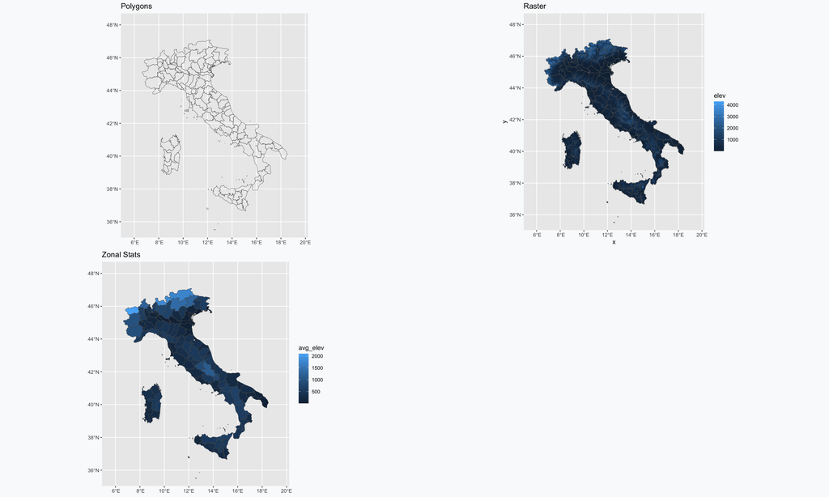

## Extracting Raster Values

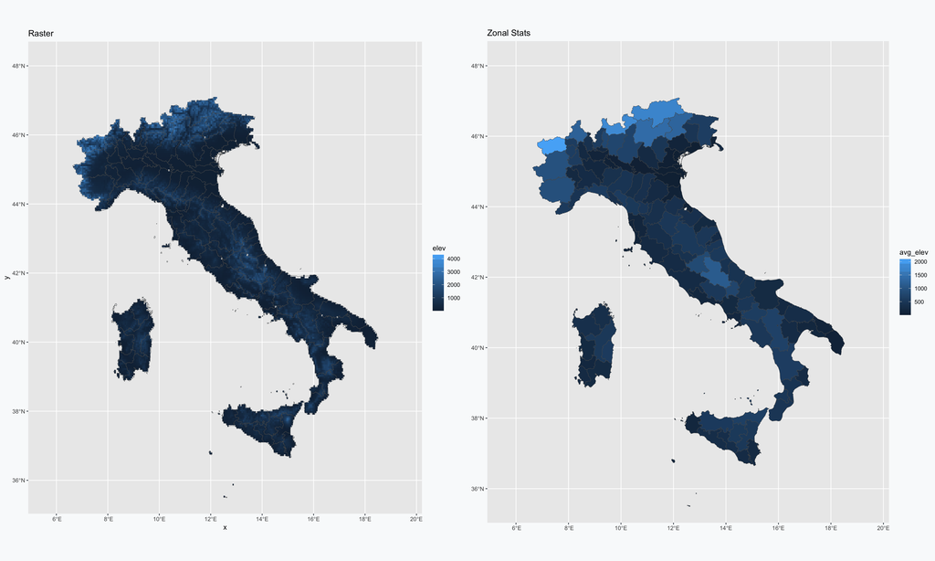

## Rasterizing Polygons

We might be interested in turning the shapefiles that we just create into a raster.

We can achieve that by using st_rasterize

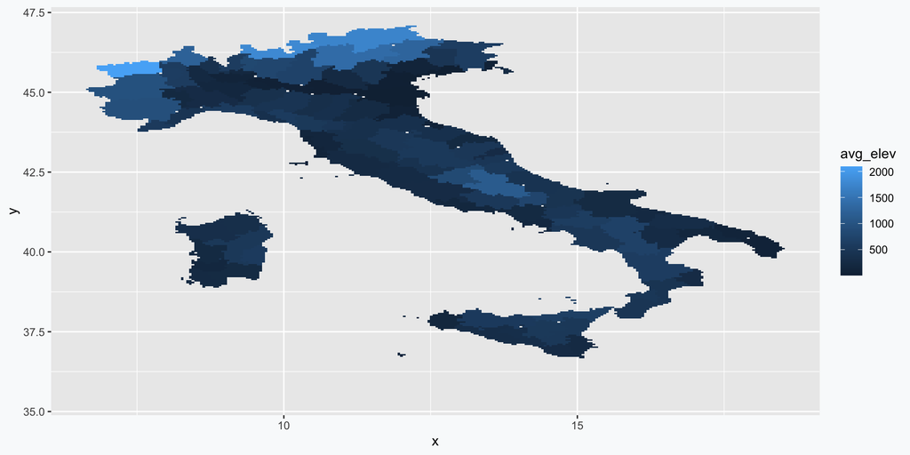

```r
poly_elev_raster<-st_rasterize(poly_elev)

ggplot()+
  geom_stars(data=poly_elev_raster)+
  scale_fill_continuous(na.value=NA)
```

## What Have We Learned?

We have learned a variety of additional raster tools:

- working with DEM (Digital Elevation Models)
- mosaicing, resampling, reprojecting rasters
- masking and cropping rasters
- turning a raster into a vector and a vector into a raster